# Lab 07 - Modelling course evaluations

Sami Munawar

2023-11-22

### Packages and Data

```r
library(tidyverse)
library(tidymodels)
evals<-read.csv("data/evals.csv", row.names=1)

view(evals)
```

# Exercise 1: Exploratory Data Analysis

1. Visualize the distribution of `score` in the dataframe `evals`.

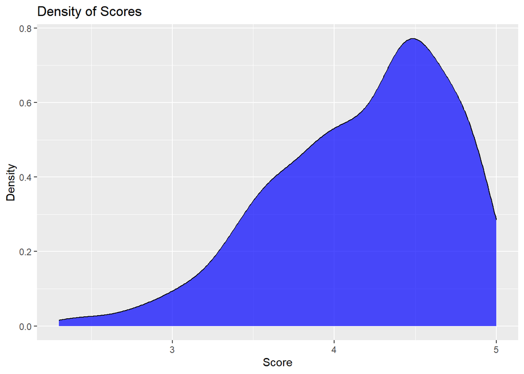

```r
ggplot(evals, aes(x = score)) +
  geom_density(fill = "blue", alpha = 0.7) +
  labs(title = "Density of Scores", x = "Score", y = "Density")
```

2. Visualize and describe the relationship between `score` and `bty_avg` using `geom_point()` to represent the data.

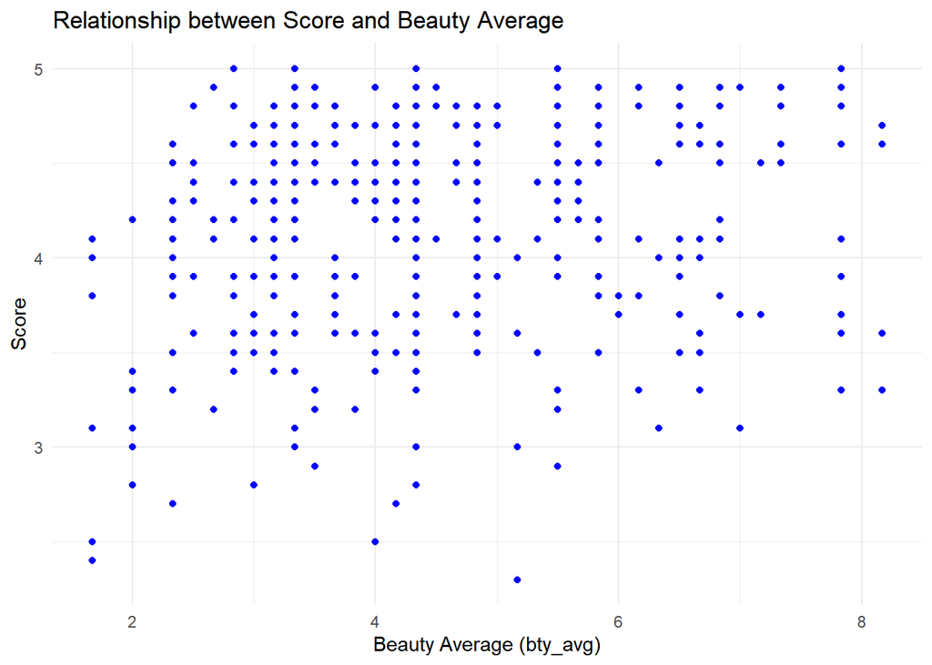

```r
ggplot(evals, aes(x = bty_avg, y = score)) +
  geom_point(colour="blue") +
  theme_minimal() +
  labs(title = "Relationship between Score and Beauty Average",
       x = "Beauty Average (bty_avg)",
       y = "Score")
```

# Exercise 2: Simple Linear regression with a numerical predictor

1. Fit a linear model called `score_bty_fit` to predict average professor evaluation `score` from average beauty rating (`bty_avg`). Print the regression output using `tidy()`.

```r
# remove eval = FALSE from the code chunk options after filling in the blanks
score_bty_fit <- linear_reg() %>%
  set_engine("lm") %>%
  fit(score ~ bty_avg, data = evals)
```

```r
# remove eval = FALSE from the code chunk options after filling in the blanks
tidy(score_bty_fit)
```

[output not shown]

2. Plot the data again using `geom_jitter()`, and add the regression line.

```r
# Create the scatter plot with jitter and add the regression line
ggplot(evals, aes(x = bty_avg, y = score)) +
  geom_jitter(width = 0.2, height = 0.2, alpha = 0.5) +
  geom_smooth(method = "lm", se = FALSE, color = "blue") +
  theme_minimal() +
  labs(title = "Relationship between Score and Beauty Average with Regression Line",
       x = "Beauty Average (bty_avg)",
       y = "Score")
```

[output not shown]

3. Interpret the slope of the linear model in context of the data.

$\text{score} = 3.88033975 + 0.06663704 \times \text{bty_avg}$

$\text{score} = 3.88033975 + 0.06663704 \times \text{(0)}$

$\text{score} = 3.88033975$

4. Interpret the intercept of the linear model in context of the data. Comment on whether or not the intercept makes sense in this context.

no in the context the intercept doesn’t make sense.

5. Determine the $R^2$ of the model and interpret it in the context of the data.

```r
# remove eval = FALSE from the code chunk options after filling in the blanks

score_bty_fit <- lm(score ~ bty_avg, data = evals)

model_summary <- summary(score_bty_fit)

summary(score_bty_fit)$r.squared
```

[output not shown]

not good fit approx 3.5% variance in the score.

6. Make a plot of residuals vs. predicted values for the model above.

```r
# remove eval = FALSE from the code chunk options after filling in the blanks
score_bty_aug <- augment(score_bty_fit)

ggplot(score_bty_aug, aes(x = .fitted, y = .resid)) +
  geom_point() +
  geom_hline(yintercept = 0, linetype = "dashed", color = "red") +
  labs(title = "Residuals vs. Fitted Values",
       x = "Fitted Values",
       y = "Residuals") +
  theme_minimal()
```

[output not shown]

# Exercise 3: Simple Linear regression with a categorical predictor

0. Look at the variable rank, and determine the frequency of each category level.

```r
# Assuming evals is your dataframe and rank is the categorical variable
rank_frequency <- table(evals$rank)

# Output the frequency of each category level
print(rank_frequency)
```

```
##
##     teaching tenure track      tenured
##          102          108          253
```

```r
rank_proportion <- prop.table(table(evals$rank))

# Output the proportion of each category level
print(rank_proportion)
```

```
##
##     teaching tenure track      tenured
##    0.2203024    0.2332613    0.5464363
```

1. Fit a new linear model called `score_rank_fit` to predict average professor evaluation `score` based on `rank` of the professor.

```r
score_rank_fit  <- linear_reg() %>%
  set_engine("lm") %>%
  fit(score ~ rank, data = evals)

tidy(score_rank_fit)
```

```
## # A tibble: 3 × 5
##   term             estimate std.error statistic   p.value
##   <chr>               <dbl>     <dbl>     <dbl>     <dbl>
## 1 (Intercept)         4.28     0.0537     79.9  1.02e-271
## 2 ranktenure track   -0.130    0.0748     -1.73 8.37e-  2
## 3 ranktenured        -0.145    0.0636     -2.28 2.28e-  2
```

2. Fit a new linear model called `score_gender_fit` to predict average professor evaluation `score` based on `gender` of the professor.

```r
score_gender_fit  <- linear_reg() %>%
  set_engine("lm") %>%
  fit(score ~ gender, data = evals)
tidy(score_gender_fit)
```

```
## # A tibble: 2 × 5
##   term        estimate std.error statistic p.value
##   <chr>          <dbl>     <dbl>     <dbl>   <dbl>
## 1 (Intercept)    4.09     0.0387    106.   0
## 2 gendermale     0.142    0.0508      2.78 0.00558
```

```r
# remove eval = FALSE from the code chunk options
score_gender_intercept <- tidy(score_gender_fit) %>%
  filter(term == "(Intercept)") %>%
  select(estimate) %>%
  pull()
```

```r
# remove eval = FALSE from the code chunk options
score_gender_slope <- tidy(score_gender_fit) %>%
  filter(term == "gendermale") %>%
  select(estimate) %>%
  pull()
```

# Exercise 4: Multiple linear regression

1. Fit a multiple linear regression model, predicting average professor evaluation `score` based on average beauty rating (`bty_avg`) and `gender.`

```r
score_bty_gender_fit <- lm(score ~ bty_avg + gender, data = evals)
summary(score_bty_gender_fit)
```

```
##
## Call:
## lm(formula = score ~ bty_avg + gender, data = evals)
##
## Residuals:
##     Min      1Q  Median      3Q     Max
## -1.8305 -0.3625  0.1055  0.4213  0.9314
##
## Coefficients:
##             Estimate Std. Error t value Pr(>|t|)
## (Intercept)  3.74734    0.08466  44.266  < 2e-16 ***
## bty_avg      0.07416    0.01625   4.563 6.48e-06 ***
## gendermale   0.17239    0.05022   3.433 0.000652 ***
## ---
## Signif. codes:  0 '***' 0.001 '**' 0.01 '*' 0.05 '.' 0.1 ' ' 1
##
## Residual standard error: 0.5287 on 460 degrees of freedom
## Multiple R-squared:  0.05912,    Adjusted R-squared:  0.05503
## F-statistic: 14.45 on 2 and 460 DF,  p-value: 8.177e-07
```

```r
library(ggplot2)

# First, create a new dataframe with the fitted values
evals$score_predicted <- fitted(score_bty_gender_fit)

# Now plot the points and add lines for the fitted values
# Assuming 'gender' is coded as 0 for females and 1 for males in your original dataframe
ggplot(evals, aes(x = bty_avg, y = score, color = gender)) +
  geom_point() +
  geom_line(aes(y = score_predicted)) +
  labs(title = "Professor Score by Beauty Average and Gender",
       x = "Beauty Average (bty_avg)",
       y = "Score") +
  theme_minimal()
```

[output not shown]

2. What percent of the variability in `score` is explained by the model `score_bty_gender_fit`.

```r
# Assuming your model is named score_bty_gender_fit and is already fitted:
summary_score_bty_gender_fit <- summary(score_bty_gender_fit)

# The R^2 value can be found in the summary object:
r_squared <- summary_score_bty_gender_fit$r.squared

# Print the R^2 value:
print(r_squared)
```

```
## [1] 0.05912279
```

```r
r_squared_percent <- r_squared * 100
print(r_squared_percent)
```

```
## [1] 5.912279
```

3. What is the equation of the line corresponding to just male professors?

4. For two professors who received the same beauty rating, which gender tends to have the higher course evaluation score?

the model predicts that the male professor would, on average, receive a higher course evaluation score compared to female professors.

5. How does the relationship between beauty and evaluation score vary between male and female professors?

the relationship between beauty and evaluation scores does not vary between genders in terms of the slope, however taking into account the added coefficient for males professors, the intercept becomes much higher larger and therefore suggests that males professors overall would receive a higher course evaluation score compared to female professors.

6. How do the adjusted $R^2$ values of `score_bty_fit` and `score_bty_gender_fit` compare?

```r
# remove eval = FALSE from the code chunk options after filling in the blanks

score_bty_fit <- lm(score ~ bty_avg, data = evals)
score_bty_gender_fit <- lm(score ~ bty_avg + gender, data = evals)

# Retrieve the adjusted R-squared values
adjusted_r2_bty <- summary(score_bty_fit)$adj.r.squared
adjusted_r2_bty_gender <- summary(score_bty_gender_fit)$adj.r.squared

# Print the adjusted R-squared values
print(adjusted_r2_bty)
print(adjusted_r2_bty_gender)

# Compare the adjusted R-squared values
if (adjusted_r2_bty > adjusted_r2_bty_gender) {
  print("The model with only beauty rating has a higher adjusted R-squared.")
} else if (adjusted_r2_bty < adjusted_r2_bty_gender) {
  print("The model with beauty rating and gender has a higher adjusted R-squared.")
} else {
  print("The adjusted R-squared values are equal.")
}
```

[output not shown]

The higher adjusted R^2 for score_bty_gender_fit indicates that this model provides a better fit to the data compared to score_bty_fit,

adding gender as a predictor alongside beauty rating improves the model’s ability to explain the variance in professor evaluation scores

7. Compare the slopes of `bty_avg` under the two models (`score_bty_fit` and `score_bty_gender_fit`).

# Exercise 5: Interpretation of log-transformed response variables

$$\begin{align*}
&\text{Given the slope coefficient } b_1 = 0.0192 \text{ in the
log-transformed model, we have:} \\
&\log(\text{price for width } (x + 1)) - \log(\text{price for width
} x) = 0.0192 \\
&\text{Using the property of logarithms (subtraction and logs):} \\
&\log\left(\frac{\text{price for width } (x + 1)}{\text{price for
width } x}\right) = 0.0192 \\
&\text{Applying the exponential function to both sides:} \\
&\exp\left(\log\left(\frac{\text{price for width } (x +
1)}{\text{price for width } x}\right)\right) = \exp(0.0192) \\
&\text{Since } e^{\log(x)} = x, \text{ we get:} \\
&\frac{\text{price for width } (x + 1)}{\text{price for width } x} =
e^{0.0192} \\
&\text{This can be rewritten as:} \\
&\text{price for width } (x + 1) = e^{0.0192} \times \text{price for
width } x \\
&\text{Hence, for each additional inch the painting is wider, the
price of the painting} \\
&\text{is expected to be higher by a factor of } e^{0.0192}. \\
&\text{Using the approximation } e^x \approx 1 + x \text{ for small
values of } x: \\
&e^{0.0192} \approx 1 + 0.0192 \\
&\text{This approximation allows us to express the factor as } 1 +
0.0192, \\
&\text{which is a 1.92\% increase.} \\
&\text{Therefore, the interpretation of the slope is:} \\
&\text{For each additional inch the painting is wider, the price of
the painting} \\
&\text{is expected to be higher, on average, by approximately
1.92\%}.
\end{align*}$$